# FPP - Ch. 8 Exercises

**8c.** Plot forecasts from an ARIMA(2,1,3) model with drift. Remove the constant and see what happens.

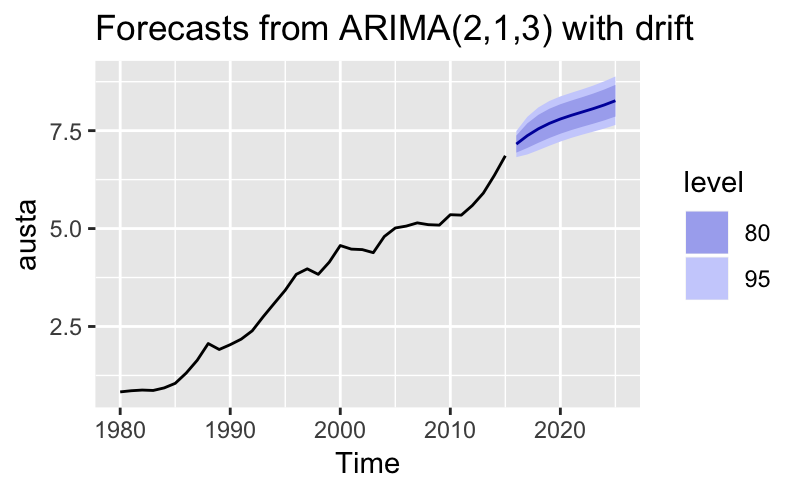

```r
Arima(austa, order=c(2,1,3), include.drift=TRUE) %>% forecast(h=10) %>% autoplot()
```

```r
Arima(austa, order=c(2,1,3), include.drift=TRUE, include.constant=FALSE) %>% forecast(h=10) %>% autoplot()
```

```
Error in stats::arima(x = x, order = order, seasonal = seasonal, include.mean = include.mean,  :
  non-stationary AR part from CSS
```

Removing the constant resulted in an error.

**8d.** Plot forecasts from an ARIMA(0,0,1) model with a constant. Remove the MA term and plot again.

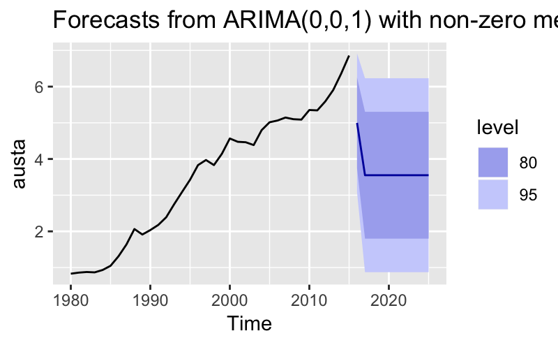

```r
Arima(austa, order=c(0,0,1), include.constant=TRUE) %>% forecast(h=10) %>% autoplot()
```

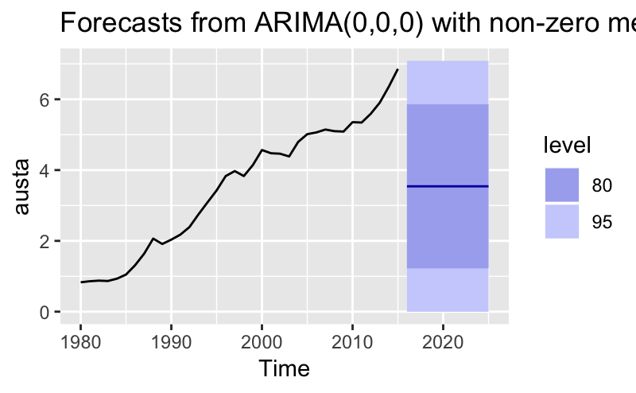

```r
Arima(austa, order=c(0,0,0), include.constant=TRUE) %>% forecast(h=10) %>% autoplot()
```

**8e.** Plot forecasts from an ARIMA(0,2,1) model with no constant.

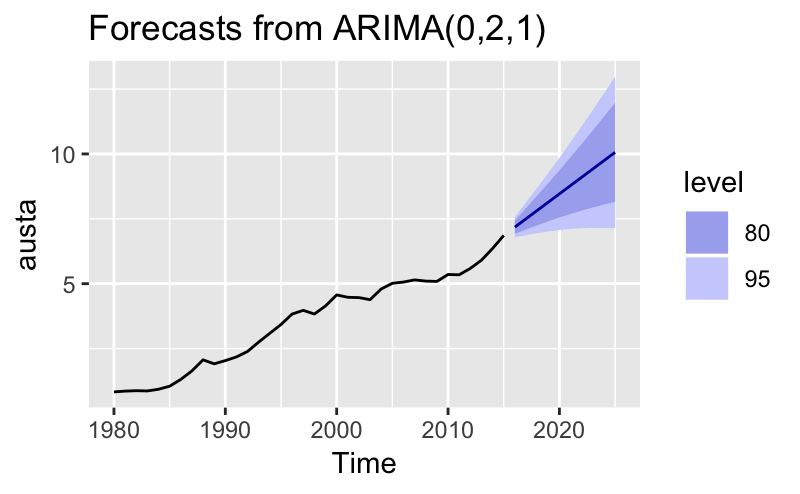

```r
Arima(austa, order=c(0,2,1), include.constant=FALSE) %>% forecast(h=10) %>% autoplot()
```

#### 9. For the `usgdp` series:

**9a.** if necessary, find a suitable Box-Cox transformation for the data;

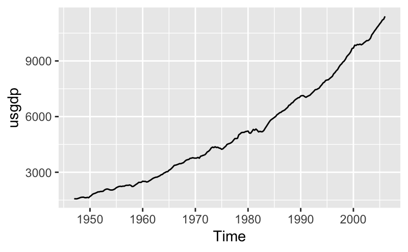

```r
autoplot(usgdp)
```

The trend seems to be accelerating (i.e., steeper incline) from around 1985.

```r
usgdp.lambda <- BoxCox.lambda(usgdp)
usgdp.lambda
```

```
[1] 0.366352
```

**9b.** fit a suitable ARIMA model to the transformed data using `auto.arima()`;

```r
usgdp.boxcox <- BoxCox(usgdp, lambda=usgdp.lambda)
fit <- auto.arima(usgdp.boxcox)
fit
```

```
Series: usgdp.boxcox
ARIMA(2,1,0) with drift

Coefficients:
         ar1     ar2   drift
      0.2795  0.1208  0.1829
s.e.  0.0647  0.0648  0.0202

sigma^2 estimated as 0.03518:  log likelihood=61.56
AIC=-115.11   AICc=-114.94   BIC=-101.26
```

**9c.** try some other plausible models by experimenting with the orders chosen;

```r
ndiffs(usgdp.boxcox)
```

```
[1] 1
```

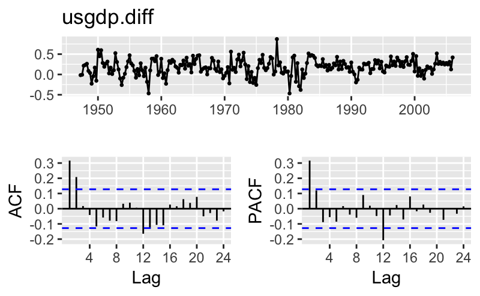

```r
usgdp.diff <- diff(usgdp.boxcox)
ggtsdisplay(usgdp.diff)
```

```r
fit_210_nodrift <- Arima(usgdp.boxcox, order=c(2,1,0), include.drift = FALSE)
fit_211_drift <- Arima(usgdp.boxcox, order=c(2,1,1), include.drift = TRUE)
#fit_211_nodrift <- Arima(usgdp.boxcox, order=c(2,1,1), include.drift = FALSE)

# no drift allowed for models with 2 differences or more
fit_220 <- Arima(usgdp.boxcox, order=c(2,2,0))
fit_221 <- Arima(usgdp.boxcox, order=c(2,2,1))
```

**8d.** choose what you think is the best model and check the residual diagnostics;

```r
paste("auto.arima(2,1,0) with drift:", round(data.frame(accuracy(fit))$RMSE, 4))
paste("auto.arima(2,1,0) w/o drift:", round(data.frame(accuracy(fit_210_nodrift))$RMSE, 4))
paste("auto.arima(2,1,1) with drift:", round(data.frame(accuracy(fit_211_drift))$RMSE, 4))
#paste("auto.arima(2,1,1) w/o drift:", round(data.frame(accuracy(fit_211_nodrift))$RMSE, 4))
paste("auto.arima(2,2,0):", round(data.frame(accuracy(fit_220))$RMSE, 4))
paste("auto.arima(2,2,1):", round(data.frame(accuracy(fit_221))$RMSE, 4))
```

[output not shown]

[output not shown]

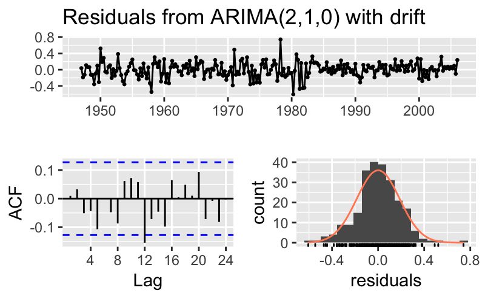

```r
checkresiduals(fit)
```

**9e.** produce forecasts of your fitted model. Do the forecasts look reasonable?

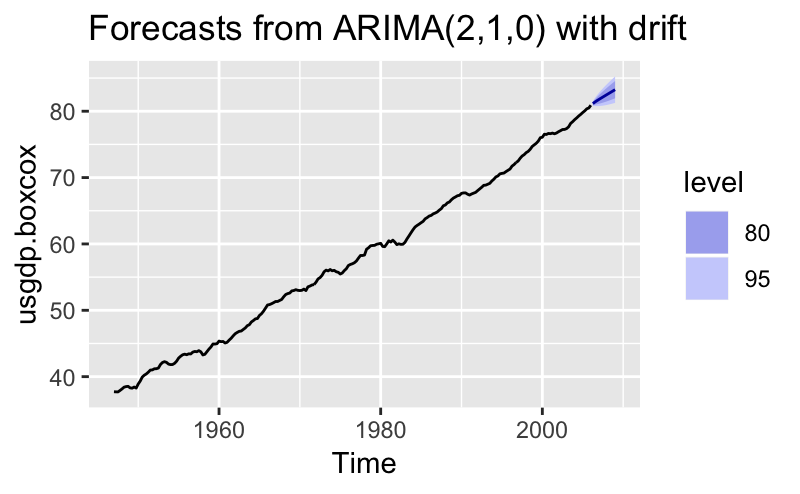

```r
autoplot(forecast(fit, h=12))
```

Forecasts for the next 12 quarters (i.e., 3 years) extend the upward trend of the dataset, so they seem reasonable.

**9f.** compare the results with what you would obtain using ets() (with no transformation).

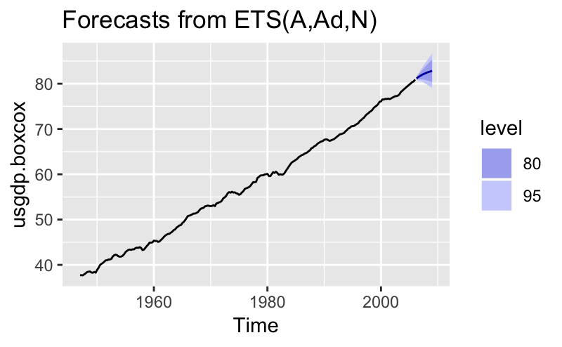

```r
fit.ets <- ets(usgdp.boxcox)
autoplot(forecast(fit.ets, h=12))
```

```r
data.frame(accuracy(fit.ets))$RMSE
```

```
[1] 0.1984366
```

The ETS model forecasts a slight dampening over time, which is not what the general positive trend in the historical data suggests. In addition, its RMSE of 0.1984366 is worse than the 0.1859861 of the ARIMA(2,1,0) model.

**10a.** Describe the time plot.

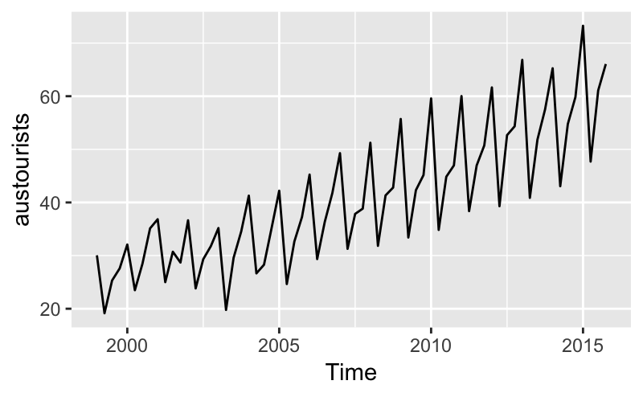

```r
autoplot(austourists)
```

The time series has a positive trend that is seasonal with increasing variance.

**10b.** What can you learn from the ACF graph?

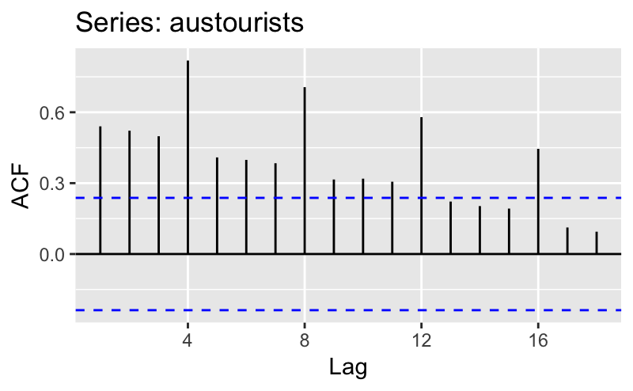

```r
ggAcf(austourists)
```

There is definitely autocorrelation and high seasonality.

**10c.** What can you learn from the PACF graph?

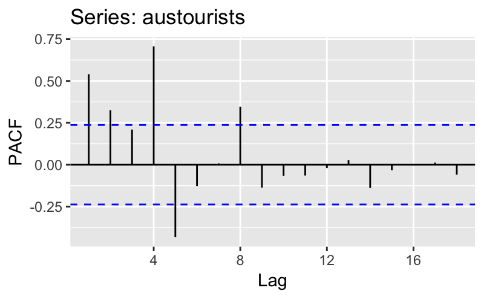

```r
ggPacf(austourists)
```

There are spikes at lag 4 and 8, also suggesting seasonality.

**10d.** Produce plots of the seasonally differenced data $(1-B^4)Y_t$. What model do these graphs suggest?

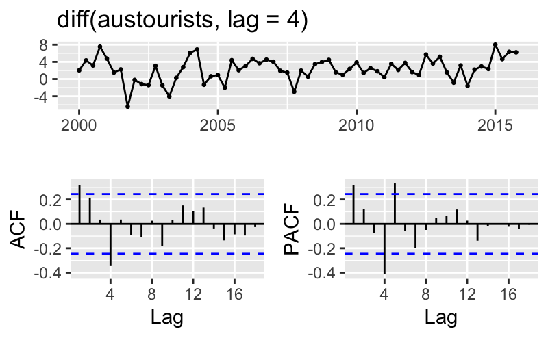

```r
ggtsdisplay(diff(austourists, lag=4))
```